# Attribute Profiles in Madden 17

**Brayden Kness & Gaurav Sharma**

### Introduction

The National Football League (NFL), is one of the most popular sporting leagues in the entire world, boasting over 100 million viewers during the [Superbowl](https://en.wikipedia.org/wiki/Super_Bowl) (Championship) alone. With its immense popularity, many people wish to participate in football, but after high school the only way to play is by being a collegiate or professional football player, both of which are incredibly different to do. Eventually Madden, a football video game, was created to allow people to simulate playing in football matches and play as real NFL teams.

A player in Madden is represented as a collection of attributes (i.e. overall rating, speed rating, strength rating, etc.), all of which are scored on a scale of 0-99. In this tutorial we will dive into the dataset of Madden 17 player ratings, looking to uncover similarities in the attribute profiles within each of the different positions, and build a model that can predict a players position, based on their attribute profile.

### Getting Started

Before we can jump into any code we need to load a couple of libraries.

Pandas: If you are not familiar with Dataframes or Pandas, GeeksForGeeks has a great [article](https://www.geeksforgeeks.org/python-pandas-dataframe) outlining the use of Dataframes, and the Pandas [documentation](https://pandas.pydata.org/pandas-docs/stable/) may be helpful.

Next we will use [Matplotlib](https://matplotlib.org) and [Seaborn](https://seaborn.pydata.org) to create and display visualizations for our data.

Lastly, we will use [Scikit-learn](https://devdocs.io/scikit_learn/) to build our prediction model.

The dataset we use in this tutorial can be found [here](https://www.pastapadre.com/2016/08/02/complete-database-of-madden-nfl-17-player-ratings). It contains the complete ratings of all attributes of players in the NFL. In addition to the attributes, it also has a players full name, team, and position.

```python
%matplotlib inline

import pandas as pd
import numpy as np
import seaborn as sns
import matplotlib.pyplot as plt
import matplotlib.ticker as ticker
from sklearn.linear_model import LinearRegression
from sklearn.linear_model import LogisticRegression
from sklearn.model_selection import train_test_split
from sklearn import metrics

pd.set_option('display.max_columns', None)
sns.set(style='whitegrid')
cmap = sns.light_palette("#2ecc71", as_cmap=True)
```

### Exploratory Data Analysis

To start off let's load the .csv file into a pandas dataframe. We can do so by using the `pd.read_csv()` method and feeding in the filename corresponding to our data.

```python
madden = pd.read_csv('madden_17.csv')
```

Let's take a look at what we have to work with.

```python
madden.head()
```

|  | Last | First | Team | Position | OVR | SPD | STR | AGI | ACC | AWR | TRK | ELU | BCV | SFA | SPM | JKM | CAR | CTH | RTE | CIT | SPC | RLS | JMP | THP | THA | SAC | MAC | DAC | RUN | … |
| --- | --- | --- | --- | --- | --- | --- | --- | --- | --- | --- | --- | --- | --- | --- | --- | --- | --- | --- | --- | --- | --- | --- | --- | --- | --- | --- | --- | --- | --- | --- |
| 0 | Miller | Von | Broncos | LOLB | 99 | 87 | 85 | 87 | 89 | 92 | 40 | 35 | 40 | 35 | 45 | 54 | 65 | 47 | 15 | 20 | 40 | 35 | 80 | 19 | 18 | 6 | 6 | 6 | 6 | … |
| 1 | Kuechly | Luke | Panthers | MLB | 99 | 86 | 81 | 85 | 89 | 98 | 54 | 30 | 46 | 49 | 35 | 45 | 64 | 81 | 15 | 50 | 45 | 12 | 90 | 25 | 25 | 6 | 6 | 6 | 6 | … |
| 2 | Gronkowski | Rob | Patriots | TE | 99 | 84 | 88 | 85 | 88 | 92 | 88 | 55 | 87 | 84 | 74 | 76 | 75 | 95 | 89 | 98 | 94 | 95 | 84 | 27 | 22 | 15 | 10 | 6 | 10 | … |
| 3 | Watt | J.J. | Texans | RE | 99 | 79 | 97 | 77 | 84 | 94 | 60 | 32 | 55 | 49 | 33 | 35 | 67 | 78 | 54 | 70 | 71 | 62 | 87 | 20 | 19 | 6 | 6 | 6 | 6 | … |
| 4 | Donald | Aaron | Rams | DT | 98 | 83 | 94 | 82 | 90 | 82 | 32 | 15 | 25 | 29 | 25 | 21 | 45 | 43 | 10 | 15 | 20 | 12 | 76 | 20 | 25 | 6 | 6 | 6 | 6 | … |

There is a lot to take in from looking at this table, so lets break it down. Aside from the first four columns, each column represents a different skill attribute. The attributes are abbreviated and can be hard to understand if you are not familiar with the game, so here is a table defining each attribute.

| ATTR | Definition |
| --- | --- |
| **OVR** | Overall |
| **SPD** | Speed |
| **STR** | Strength |
| **AGI** | Agility |
| **ACC** | Acceleration |
| **AWR** | Awareness |
| **TRK** | Trucking |
| **ELU** | Elusiveness |
| **BCV** | Ball Carrier Vision |
| **SFA** | Stiff Arm |
| **SPM** | Spin Move |
| **JKM** | Juke Move |
| **CAR** | Carrying |
| **CTH** | Catching |
| **RTE** | Route Running |

| ATTR | Definition |
| --- | --- |
| **CIT** | Catch in Traffic |
| **SPC** | Spectacular Catch |
| **RLS** | Release |
| **JMP** | Jumping |
| **THP** | Throwing Power |
| **THA** | Throwing Accuracy |
| **SAC** | Short Pass Accuracy |
| **MAC** | Medium Pass Accuracy |
| **DAC** | Deep Pass Accuracy |
| **RUN** | Throw on the Run |
| **PAC** | Play Action |
| **TAK** | Tackling |
| **POW** | Hit Power |
| **PMV** | Power Move |
| **FMV** | Finesse Move |

| ATTR | Definition |
| --- | --- |
| **BSH** | Block Shedding |
| **PUR** | Pursuit |
| **PRC** | Play Recognition |
| **MCV** | Man Coverage |
| **ZCV** | Zone Coverage |
| **PRS** | Press Coverage |
| **KPW** | Kicking Power |
| **KAC** | Kicking Accuracy |
| **IBL** | Inside Blocking |
| **RBK** | Run Blocking |
| **PBK** | Pass Blocking |
| **RET** | Kick/Punt Returning |
| **TGH** | Toughness |
| **STA** | Stamina |
| **INJ** | Injury |

Clearly, this dataset contains a plethora of information, so let's visualize different aspects of the data to see if there is anything interesting to explore further, or if any particular trends seem to stand out moreso than others.

The first thing that we will to look at is how many players there are at each position. We will use Panda's `groupby()` method to group all of the rows by position.

```python
by_position = madden.groupby('Position')
```

Next we will count the number of players at each position.

```python
counts = by_position.count().iloc[:, 0].sort_values(ascending=False)
```

Now lets make a bar plot showing the number of players at each position.

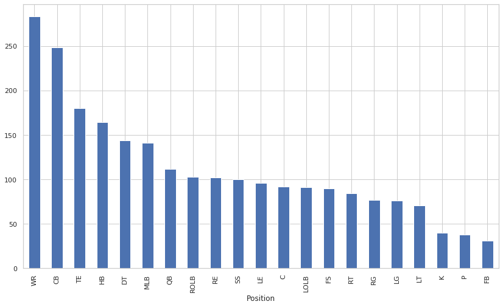

```python
counts.plot(kind='bar', figsize=(14, 8));
```

After plotting, it is clear that wide receiver and cornerback are the two most common positions in the dataset. This makes sense given that on any particular play, there are usually 3 wide receivers and cornerbacks on the field, while most other positions will have just 1 on the field. Kicker punter and fullback also make sense to have the least amount of players, as many teams don’t utilize the fullback position, and since kicker and punter are on the field for a very short amount of time and don’t typically have any contact, there isn’t need for many backups.

The next thing we want to look at is the distribution of overall ratings. We will use the `distplot()` method from the Seaborn library to achieve this.

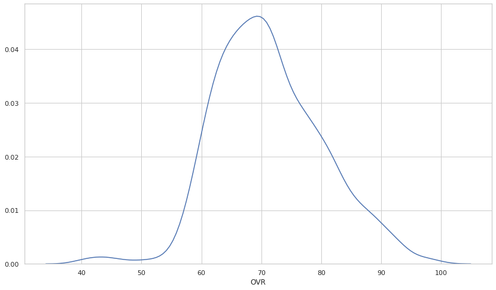

```python
plt.figure(figsize=(14, 8))
sns.distplot(madden['OVR'], hist=False);
```

The distribution of overall ratings is positively skewed, meaning that the mean of the distribution is greater than the median. This makes sense logically because an NFL roster has 53 players but only 11 can be on the field at a time, so the majority of players have average to low ratings.

Now let's look into the average rating by position. We follow the same process that we used above, but this time we are getting the mean instead of the count. This gives us the plot below.

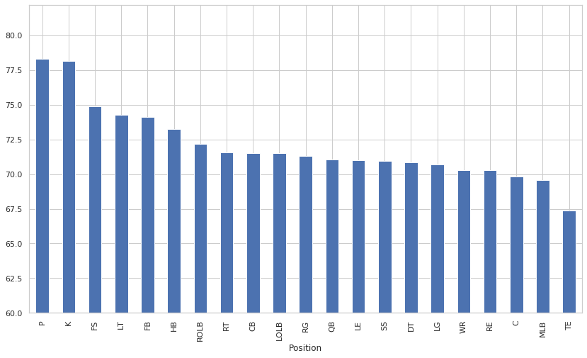

```python
means = by_position.mean()
sorted_means = means['OVR'].sort_values(ascending=False)
ax = sorted_means.plot(kind='bar', figsize=(14, 8))
ax.set_ylim(60);
```

Punters and kickers are the highest rated, which makes sense, since each team has only one or two, they must be the best possible players at their posiitons. Interestingly, tight end is substantially lower than all the other positions.

Given that each position requires a different set of skills, let's see if we can find a pattern in the attribute profiles between positions. To do this we will look at a cluster map of attributes by position.

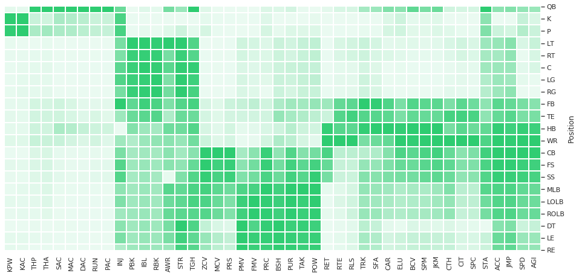

```python
cluster = sns.clustermap(means.drop(columns='OVR'), cmap=cmap,
                         square=True, linewidths=1, linecolor='w',
                         standard_scale=1, figsize=(20, 10))

cluster.ax_row_dendrogram.set_visible(False)
cluster.ax_col_dendrogram.set_visible(False)
cluster.cax.set_visible(False)
```

In this plot each row represents a given position, and each column a given attribute. The transparency level for each block shows the average score for a given position and attribute. By looking at this graph we can clearly see that there are distinctions in the attribute profile for each position.

Now let’s look at the highest average attribute for each position, and see how they differ. To do this we apply the `idxmax()` method on each row. The idmax method will give the column (attribute) name corresponding to the highest value in each row. Here we have those shown.

```python
means.apply(lambda x: x.idxmax(), axis=1)
```

```
Position
C       INJ
CB      STA
DT      INJ
FB      INJ
FS      ACC
HB      ACC
K       KPW
LE      INJ
LG      INJ
LOLB    INJ
LT      INJ
MLB     STA
P       KPW
QB      STA
RE      INJ
RG      INJ
ROLB    INJ
RT      INJ
SS      INJ
TE      INJ
WR      ACC
dtype: object
```

Overall we see that most positions have their highest attribute being INJ. The INJ rating represents a given player’s susceptibility to injure themselves during a game. INJ is a dynamic stat that will lower during a period where that player is dealing with injury, generating an in game risk of playing injured.

The fact that INJ is consistently the highest suggests that it has little significance to the attribute makeup of a given position, and all positions will have a relatively high INJ rating. Let's explore the variation in INJ by position with a point plot.

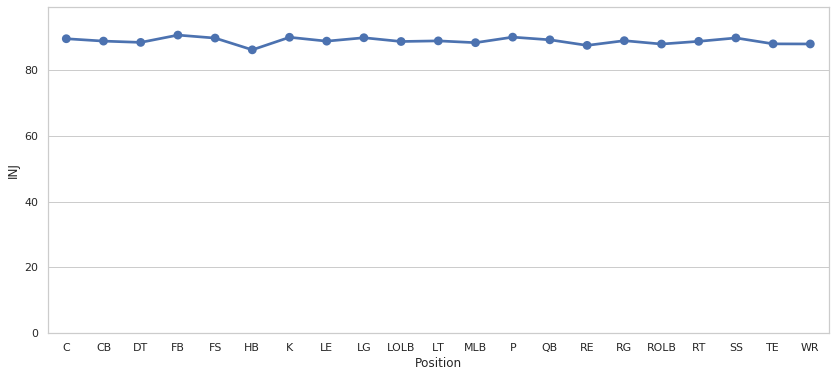

```python
plt.figure(figsize=(14, 6))
ax = sns.pointplot(x='Position', y='INJ', data=means.reset_index())

plt.setp(ax, ylim=(0, 99));
```

From this plot we see that there is in fact little to no variation by positions. Let's compare this to attributes that we might expect to have high variation, for example, throwing power (THP) and speed (SPD). We expect to see high variability for speed between positions (think lineman versus running back) and a spike in throwing power for quarterbacks.

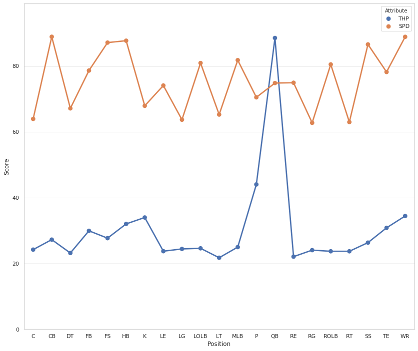

```python
plt.figure(figsize=(14, 12))

thp_spd = means.reset_index().melt(id_vars=['Position'],
                                 value_vars=['THP', 'SPD'],
                                 var_name='Attribute',
                                 value_name='Score')

ax = sns.pointplot(x='Position', y='Score', data=thp_spd, hue='Attribute')
plt.setp(ax, ylim=(0, 99));
```

Speed is an interesting one, as we see that players that are typically bigger have lower speed values while more skill oriented players have higher speed values. This makes us believe that we may be able to predict a player's position based on their attribute profile.

Let's now look at the distribution of attributes and their scores. To do this we will plot a heat map. Now, attributes range from 0 - 99, so we will split the scores into tiers (i.e. a rating of 87 would fall into the 80 tier) and use the number of players whose attributes fall into a given tier to shade the heat map.

Before we do this let's define a method that will allow us to easily plot heat maps.

```python
def heat_plot(corr, ax, cmap=sns.light_palette("#2ecc71", as_cmap=True)):
    hm = sns.heatmap(corr, cmap=cmap, square=True,
                     linewidths=2, linecolor='w',
                     annot=False, ax=ax)

    bottom, top = hm.get_ylim()
    hm.set_ylim(bottom + 0.5, top - 0.5)
    return hm
```

Now we can manipulate the data, and plot the relation. Let's use the Pandas method `melt()` to reshape the data frame in such a way that we get a column for the attribute name, and a column for the attribute score.

```python
attributes = madden.melt(value_vars=madden.columns[5:],
                   var_name ='Attribute', value_name ='Score')
```

Here is what our data now looks like.

```python
attributes.head()
```

|  | Attribute | Score |
| --- | --- | --- |
| 0 | SPD | 87 |
| 1 | SPD | 86 |
| 2 | SPD | 84 |
| 3 | SPD | 79 |
| 4 | SPD | 83 |

Now we can organize the scores by tier, let's do so by using integer division to divide the score values by 10, which will cutoff '1s' place of the score, and then multiplying by 10.

```python
attributes['Tier'] = (attributes.Score // 10) * 10
```

Let's look at the results.

```python
attributes.head()
```

|  | Attribute | Score | Tier |
| --- | --- | --- | --- |
| 0 | SPD | 87 | 80 |
| 1 | SPD | 86 | 80 |
| 2 | SPD | 84 | 80 |
| 3 | SPD | 79 | 70 |
| 4 | SPD | 83 | 80 |

Now that we have defined a tier value for each score, we can group the data by attribute and tier, and count the occurences of each attribute, in each tier.

```python
tiers = attributes.groupby(['Attribute', 'Tier']).count().reset_index()
tiers.reset_index(inplace=True)
```

Now we can format the data for a heat map by pivoting on the `Tier` column.

```python
heat = tiers.pivot(index='Tier', columns='Attribute', values='Score')
heat = heat.reindex(index=heat.index[::-1])
```

Our data now looks like this.

```python
heat
```

| Attribute Tier | ACC | AGI | AWR | BCV | BSH | CAR | CIT | CTH | DAC | ELU | FMV | IBL | INJ | JKM | JMP | KAC | KPW | MAC | MCV | PAC | PBK | PMV | POW | PRC | PRS | PUR | RBK | RET | RLS | … |
| --- | --- | --- | --- | --- | --- | --- | --- | --- | --- | --- | --- | --- | --- | --- | --- | --- | --- | --- | --- | --- | --- | --- | --- | --- | --- | --- | --- | --- | --- | --- |
| 90 | 513.0 | 293.0 | 83.0 | 52.0 | 38.0 | 11.0 | 24.0 | 30.0 | 2.0 | 34.0 | 14.0 | 24.0 | 1121.0 | 70.0 | 300.0 | 24.0 | 58.0 | 10.0 | 9.0 | 4.0 | 17.0 | 38.0 | 32.0 | 31.0 | 12.0 | 34.0 | 27.0 | 13.0 | 13.0 | … |
| 80 | 1312.0 | 884.0 | 373.0 | 273.0 | 178.0 | 107.0 | 129.0 | 176.0 | 16.0 | 155.0 | 63.0 | 136.0 | 1083.0 | 315.0 | 1069.0 | 50.0 | 20.0 | 29.0 | 63.0 | 14.0 | 93.0 | 134.0 | 311.0 | 182.0 | 77.0 | 386.0 | 135.0 | 96.0 | 73.0 | … |
| 70 | 477.0 | 520.0 | 551.0 | 360.0 | 359.0 | 388.0 | 280.0 | 419.0 | 73.0 | 284.0 | 166.0 | 256.0 | 152.0 | 443.0 | 563.0 | 5.0 | 2.0 | 71.0 | 275.0 | 57.0 | 325.0 | 307.0 | 438.0 | 248.0 | 162.0 | 543.0 | 310.0 | 198.0 | 168.0 | … |
| 60 | 57.0 | 409.0 | 597.0 | 294.0 | 240.0 | 703.0 | 225.0 | 451.0 | 25.0 | 329.0 | 263.0 | 205.0 | 7.0 | 280.0 | 243.0 | 2.0 | 7.0 | 10.0 | 240.0 | 31.0 | 126.0 | 206.0 | 213.0 | 309.0 | 174.0 | 183.0 | 152.0 | 184.0 | 209.0 | … |
| 50 | 4.0 | 228.0 | 486.0 | 184.0 | 218.0 | 340.0 | 183.0 | 342.0 | 9.0 | 181.0 | 264.0 | 135.0 | NaN | 128.0 | 84.0 | 7.0 | 3.0 | 13.0 | 194.0 | 10.0 | 158.0 | 120.0 | 106.0 | 248.0 | 164.0 | 85.0 | 139.0 | 135.0 | 151.0 | … |
| 40 | NaN | 29.0 | 264.0 | 182.0 | 390.0 | 576.0 | 284.0 | 328.0 | 16.0 | 202.0 | 236.0 | 1124.0 | NaN | 152.0 | 56.0 | 10.0 | 17.0 | 24.0 | 44.0 | 8.0 | 1131.0 | 164.0 | 139.0 | 162.0 | 171.0 | 249.0 | 1183.0 | 166.0 | 133.0 | … |
| 30 | NaN | NaN | 9.0 | 175.0 | 356.0 | 177.0 | 179.0 | 346.0 | 40.0 | 284.0 | 185.0 | 204.0 | NaN | 188.0 | 26.0 | 165.0 | 173.0 | 168.0 | 48.0 | 22.0 | 161.0 | 156.0 | 133.0 | 108.0 | 80.0 | 508.0 | 139.0 | 135.0 | 165.0 | … |
| 20 | NaN | NaN | NaN | 225.0 | 422.0 | 60.0 | 205.0 | 238.0 | 192.0 | 308.0 | 123.0 | 172.0 | NaN | 145.0 | 20.0 | 1107.0 | 1268.0 | 122.0 | 231.0 | 111.0 | 188.0 | 205.0 | 409.0 | 586.0 | 263.0 | 300.0 | 199.0 | 62.0 | 384.0 | … |
| 10 | NaN | NaN | NaN | 618.0 | 160.0 | NaN | 852.0 | 33.0 | 270.0 | 585.0 | 1002.0 | 104.0 | NaN | 642.0 | 2.0 | 966.0 | 790.0 | 494.0 | 1233.0 | 377.0 | 162.0 | 981.0 | 576.0 | 485.0 | 1208.0 | 75.0 | 77.0 | 1241.0 | 1065.0 | … |
| 0 | NaN | NaN | NaN | NaN | 2.0 | 1.0 | 2.0 | NaN | 1720.0 | 1.0 | 47.0 | 3.0 | NaN | NaN | NaN | 27.0 | 25.0 | 1422.0 | 26.0 | 1729.0 | 2.0 | 52.0 | 6.0 | 4.0 | 52.0 | NaN | 2.0 | 133.0 | 2.0 | … |

Lastly, before we plot the heat map, lets arrange the attributes by their given ranges, so the attribute with the smallest range will be at the left of our plot, and the attribute with the largest range will be at the right.

```python
ranges = madden.iloc[:, 5:].apply(lambda x: max(x) - min(x))
ranges.sort_values(inplace=True)
heat = heat[ranges.keys()]
```

Now let's plot the heat map using the method defined above.

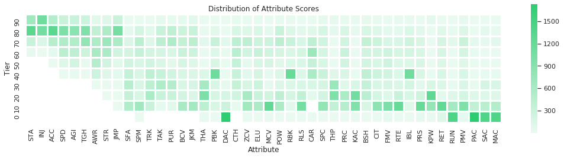

```python
fig, axs = plt.subplots(figsize=(18, 4))
axs.set_title('Distribution of Attribute Scores')
heat_plot(heat, axs);
```

This plot gives us a good look at the distribution of attribute scores. We can see that INJ is the attribute with the second lowest range, supporting our hypothesis above. It is also clear that the data is quite sloppy. Each attribute is weighted on the same scale, and that is not helpful in analyzing which attributes are significant to a given position. We want to look at how a given attribute rating compares to the other ratings for that attribute.

We can accomplish this by standardizing our variable. We will center and scale the attribute values, so that they are scored based on standard deviations away from the mean. We will standardize the data based on this formula `(x - mean) / std`.

```python
madden.iloc[:, 5:] = madden.iloc[:, 5:].apply(lambda x: (x - x.mean()) / x.std())
```

Let's see what our standardized data looks like.

```python
madden.head()
```

|  | Last | First | Team | Position | OVR | SPD | STR | AGI | ACC | AWR | TRK | ELU | BCV | SFA | SPM | JKM | CAR | CTH | RTE | CIT | SPC | RLS | JMP | THP | THA | SAC | MAC | DAC | RUN | … |
| --- | --- | --- | --- | --- | --- | --- | --- | --- | --- | --- | --- | --- | --- | --- | --- | --- | --- | --- | --- | --- | --- | --- | --- | --- | --- | --- | --- | --- | --- | --- |
| 0 | Miller | Von | Broncos | LOLB | 99 | 0.814803 | 1.065888 | 0.867902 | 0.711448 | 1.879703 | 0.027056 | -0.316627 | -0.245194 | -0.157063 | -0.012385 | 0.199116 | 0.547303 | -0.397808 | -0.676311 | -0.763744 | -0.024325 | 0.110575 | 0.129849 | -0.704006 | -0.750479 | -0.524444 | -0.462446 | -0.397236 | -0.418511 | … |
| 1 | Kuechly | Luke | Panthers | MLB | 99 | 0.719313 | 0.751670 | 0.701112 | 0.711448 | 2.322747 | 0.738543 | -0.515572 | -0.027117 | 0.511573 | -0.377282 | -0.113539 | 0.481062 | 1.397938 | -0.676311 | 0.421471 | 0.171717 | -0.885387 | 0.911393 | -0.332799 | -0.249766 | -0.524444 | -0.462446 | -0.397236 | -0.418511 | … |
| 2 | Gronkowski | Rob | Patriots | TE | 99 | 0.528331 | 1.301552 | 0.701112 | 0.558505 | 1.879703 | 2.466440 | 0.479150 | 1.463074 | 2.183163 | 1.045819 | 0.963385 | 1.209706 | 2.137362 | 2.492103 | 2.317814 | 2.092931 | 2.708737 | 0.442467 | -0.209063 | -0.464357 | -0.035905 | -0.230646 | -0.397236 | -0.178622 | … |
| 3 | Watt | J.J. | Texans | RE | 99 | 0.050877 | 2.008543 | 0.033951 | -0.053268 | 2.027384 | 1.043466 | -0.435994 | 0.299998 | 0.511573 | -0.450262 | -0.460934 | 0.679783 | 1.239489 | 0.993529 | 1.211614 | 1.191137 | 1.279748 | 0.676930 | -0.642138 | -0.678949 | -0.524444 | -0.462446 | -0.397236 | -0.418511 | … |
| 4 | Donald | Aaron | Rams | DT | 98 | 0.432840 | 1.772879 | 0.450926 | 0.864391 | 1.141296 | -0.379509 | -1.112405 | -0.790386 | -0.443622 | -0.742180 | -0.947287 | -0.777504 | -0.609072 | -0.890393 | -0.961279 | -0.808494 | -0.885387 | -0.182768 | -0.642138 | -0.249766 | -0.524444 | -0.462446 | -0.397236 | -0.418511 | … |

Now let's plot the same heat map as above, but with our newly scaled and centered data.

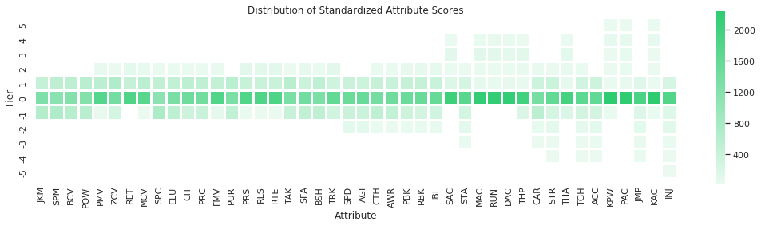

```python
std_attributes = madden.melt(value_vars=madden.columns[5:],
                   var_name ='Attribute', value_name ='Score')

std_attributes['Tier'] = std_attributes.Score.astype('int')

std_tiers = std_attributes.groupby(['Attribute', 'Tier']).count()
std_tiers.reset_index(inplace=True)

std_heat = std_tiers.pivot(index='Tier', columns='Attribute', values='Score')
std_heat = std_heat.reindex(index=std_heat.index[::-1])

std_ranges = madden.iloc[:, 5:].apply(lambda x: max(x) - min(x))
std_ranges.sort_values(inplace=True)

std_heat = std_heat[std_ranges.keys()]

fig, axs = plt.subplots(figsize=(18, 4))
axs.set_title('Distribution of Standardized Attribute Scores')
heat_plot(std_heat, axs);
```

This looks much nicer, and the attribute values are very clearly centered around their respective means. Now that the data is standardized let's once again look at the highest average by position

```python
means = madden.groupby('Position').mean().drop(columns='OVR')
means.apply(lambda x: x.idxmax(), axis=1)
```

```
Position
C       IBL
CB      PRS
DT      PMV
FB      TRK
FS      PRS
HB      TRK
K       KPW
LE      PMV
LG      RBK
LOLB    FMV
LT      PBK
MLB     TAK
P       KAC
QB      PAC
RE      PMV
RG      RBK
ROLB    FMV
RT      PBK
SS      PRS
TE      RLS
WR      RTE
dtype: object
```

We can now start to see the relevant attributes to each position, notice that none of which are INJ.

Now that we have clearly shown that certain ratings correspond moreso to certain positions than others, lets build a model and train it on the data set, with the goal of predicting a player's position based on his ratings.

The first step is to split our data into features (independent variables) and labels (dependent variables). Since we are trying to predict a player's *Position* based on his *attributes* we will make our features the player's attributes and the labels the player's position.

```python
# Features
X = madden.iloc[:, 5:]

# Labels
y = madden['Position'].values.ravel()
```

Next, in order to accurately train and test our model we will need to split the features and labels into training and testing sets. This task is easily accomplished using the `train_test_split()` method from the sklearn library. The parameter test_size is what percentage of the dataset will be used for testing. We chose 30 percent, but feel free to play around with other values.

```python
X_train, X_test, y_train, y_test = train_test_split(X, y, test_size=0.3)
```

We now have everything we need to build, train, and test a regression model. Since we are trying to predict a categorical variable (i.e. position) we will use a Logisitic Regression model. If you are unfamiliar with Logistic Regression, [here](https://www.youtube.com/watch?v=yIYKR4sgzI8&t=375s) is a very nice video explaining the topic.

To build our model we will use the `LogisticRegression` class from thew sklearn library, and fit our training sets to the model.

```python
regressor = LogisticRegression(solver='liblinear', multi_class='ovr')
regressor.fit(X_train, y_train);
```

With the model fit to our training sets, we can score the accuracy of the model by using the `score()` method, from the `LogisiticRegression` class, feeding in our testing sets.

```python
score = regressor.score(X_test, y_test)
predictions = regressor.predict(X_test)
```

Here is our score

```python
score
```

```
0.6558533145275035
```

To get a better feel for our model's accuracy, let's look at a confusion matrix of our predicted labels and true labels.

Before we do this, we will define another method that will let us easily compute and plot a confusion matrix, this will make it much easier to derive meaning from the matrix.

```python
def plot_cm(actual, predicted, score,
            figsize=(12, 12),
            cmap=sns.light_palette("#2ecc71", as_cmap=True)):

    labels = list(set(predicted))
    cm = metrics.confusion_matrix(actual, predicted, labels)

    plt.figure(figsize=figsize)
    ax = sns.heatmap(cm, annot=True, fmt="d", linewidths=.5, square=True, cbar=False, cmap=cmap)

    bottom, top = ax.get_ylim()
    ax.set_ylim(bottom + 0.5, top - 0.5)

    ax.set(xticklabels=labels)
    ax.set(yticklabels=labels)

    plt.ylabel('Actual Position');
    plt.xlabel('Predicted Position');

    all_sample_title = 'Accuracy Score: {0}'.format(score)
    plt.title(all_sample_title, size = 15);
    return ax
```

Now let's inspect the matrix.

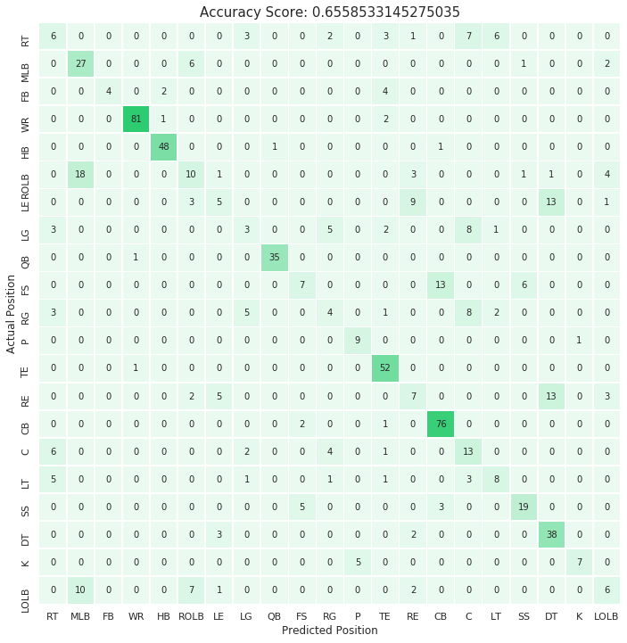

```python
plot_cm(y_test, predictions, score);
```

By analyzing this plot, we notice that most of the confusion comes when players are of a similar type, such as confusing two offensive lineman positions. This also makes sense since many players in Madden will play multiple positions, but can only be listed as one.

Let's now try to improve the accuracy by categorizing players into similar categories, such as offensive lineman. Here are the categories that we chose.

```python
# Offensive: Backs, Line, Receivers, QB
OLine = ['LT', 'LG', 'C', 'RG', 'RT']
Backs = ['HB', 'FB']
Receivers = ['WR', 'TE']
QB = ['QB']

# Defensive
Secondary = ['CB', 'SS', 'FS']
Linebackers = ['LOLB', 'MLB', 'ROLB']
Ends = ['RE', 'LE']
DT = ['DT']

# Kickers
Kickers = ['P', 'K']
```

We were careful to only include interchangeable positions to avoid oversimplifying our model.

Let's now place each player into their respective category. First, we need to define a function that will take in a position, and return a category.

```python
def cat(pos):
    if pos in OLine:
        return 'OLine'
    elif pos in Backs:
        return 'Back'
    elif pos in Receivers:
        return 'Receiver'
    elif pos in QB:
        return 'QB'
    elif pos in Linebackers:
        return 'Linebacker'
    elif pos in Secondary:
        return 'Secondary'
    elif pos in Ends:
        return 'End'
    elif pos in DT:
        return 'DT'
    elif pos in Kickers:
        return 'Kicker'
    else:
        return ''
    return
```

We can now apply this method to our data.

```python
madden['Position'] = madden['Position'].apply(cat)
```

Let's take a look at the changes.

```python
madden.head()
```

|  | Last | First | Team | Position | OVR | SPD | STR | AGI | ACC | AWR | TRK | ELU | BCV | SFA | SPM | JKM | CAR | CTH | RTE | CIT | SPC | RLS | JMP | THP | THA | SAC | MAC | DAC | RUN | … |
| --- | --- | --- | --- | --- | --- | --- | --- | --- | --- | --- | --- | --- | --- | --- | --- | --- | --- | --- | --- | --- | --- | --- | --- | --- | --- | --- | --- | --- | --- | --- |
| 0 | Miller | Von | Broncos | Linebacker | 99 | 0.814803 | 1.065888 | 0.867902 | 0.711448 | 1.879703 | 0.027056 | -0.316627 | -0.245194 | -0.157063 | -0.012385 | 0.199116 | 0.547303 | -0.397808 | -0.676311 | -0.763744 | -0.024325 | 0.110575 | 0.129849 | -0.704006 | -0.750479 | -0.524444 | -0.462446 | -0.397236 | -0.418511 | … |
| 1 | Kuechly | Luke | Panthers | Linebacker | 99 | 0.719313 | 0.751670 | 0.701112 | 0.711448 | 2.322747 | 0.738543 | -0.515572 | -0.027117 | 0.511573 | -0.377282 | -0.113539 | 0.481062 | 1.397938 | -0.676311 | 0.421471 | 0.171717 | -0.885387 | 0.911393 | -0.332799 | -0.249766 | -0.524444 | -0.462446 | -0.397236 | -0.418511 | … |
| 2 | Gronkowski | Rob | Patriots | Receiver | 99 | 0.528331 | 1.301552 | 0.701112 | 0.558505 | 1.879703 | 2.466440 | 0.479150 | 1.463074 | 2.183163 | 1.045819 | 0.963385 | 1.209706 | 2.137362 | 2.492103 | 2.317814 | 2.092931 | 2.708737 | 0.442467 | -0.209063 | -0.464357 | -0.035905 | -0.230646 | -0.397236 | -0.178622 | … |
| 3 | Watt | J.J. | Texans | End | 99 | 0.050877 | 2.008543 | 0.033951 | -0.053268 | 2.027384 | 1.043466 | -0.435994 | 0.299998 | 0.511573 | -0.450262 | -0.460934 | 0.679783 | 1.239489 | 0.993529 | 1.211614 | 1.191137 | 1.279748 | 0.676930 | -0.642138 | -0.678949 | -0.524444 | -0.462446 | -0.397236 | -0.418511 | … |
| 4 | Donald | Aaron | Rams | DT | 98 | 0.432840 | 1.772879 | 0.450926 | 0.864391 | 1.141296 | -0.379509 | -1.112405 | -0.790386 | -0.443622 | -0.742180 | -0.947287 | -0.777504 | -0.609072 | -0.890393 | -0.961279 | -0.808494 | -0.885387 | -0.182768 | -0.642138 | -0.249766 | -0.524444 | -0.462446 | -0.397236 | -0.418511 | … |

By looking at the `Position` column you will notice that the players are now properly categorized.

Let's now follow the same process as above to build, train, and test a logistic regression model to our data, only this time it will be predicting the category, as opposed to the specific position.

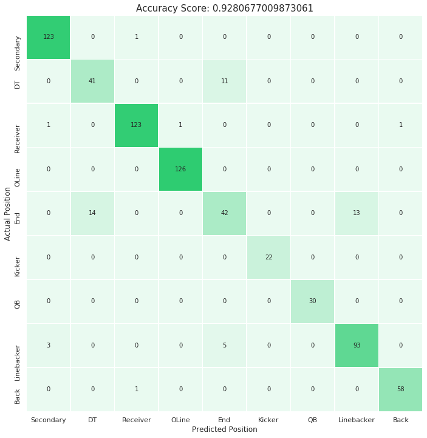

```python
X = madden.iloc[:, 5:]
y = madden['Position'].values.ravel()

X_train, X_test, y_train, y_test = train_test_split(X, y, test_size=0.3, random_state=42)

regressor = LogisticRegression(solver='liblinear', multi_class='ovr').fit(X_train, y_train)

score = regressor.score(X_test, y_test)
predictions = regressor.predict(X_test)

plot_cm(y_test, predictions, score);
```

When using these new categories, we see that our model now has an extremely impressive 92% accuracy. This means that we can, with immense accuracy, predict which type of player a person is based purely off of their attribute ratings.

### Conclusion

What we’ve learned from all of this is that to be successful at each position, there is a distinct set of attributes that the player must be good at to succeed enough to make it to the NFL, therefore to be able to be in the Madden game. If this wasn’t the case, we would not have been able to make predictions with nearly as much accuracy as we were able to do.

Thank you for completing the tutorial, we hope you learned a lot from it.